# Risk Factor Analysis

## Outcome Variable

**Outcome Variable:** ever_stunted

## Predictor Variables

**Intervention Variable:** single

**Adjustment Set:**

unadjusted

## Stratifying Variables

The analysis was stratified on these variable(s):

- agecat
- studyid
- country

## Data Summary

| agecat | studyid | country | A | n | nA | nAY0 | nAY1 |
| --- | --- | --- | --- | --- | --- | --- | --- |
| 3 months | ki0047075b-MAL-ED | BANGLADESH | 0 | 265 | 265 | 187 | 78 |
| 3 months | ki0047075b-MAL-ED | BANGLADESH | 1 | 265 | 0 | 0 | 0 |
| 3 months | ki0047075b-MAL-ED | BRAZIL | 0 | 233 | 197 | 168 | 29 |
| 3 months | ki0047075b-MAL-ED | BRAZIL | 1 | 233 | 36 | 27 | 9 |
| 3 months | ki0047075b-MAL-ED | INDIA | 0 | 249 | 249 | 183 | 66 |
| 3 months | ki0047075b-MAL-ED | INDIA | 1 | 249 | 0 | 0 | 0 |
| 3 months | ki0047075b-MAL-ED | NEPAL | 0 | 240 | 240 | 202 | 38 |
| 3 months | ki0047075b-MAL-ED | NEPAL | 1 | 240 | 0 | 0 | 0 |
| 3 months | ki0047075b-MAL-ED | PERU | 0 | 303 | 268 | 179 | 89 |
| 3 months | ki0047075b-MAL-ED | PERU | 1 | 303 | 35 | 23 | 12 |
| 3 months | ki0047075b-MAL-ED | SOUTH AFRICA | 0 | 314 | 176 | 138 | 38 |
| 3 months | ki0047075b-MAL-ED | SOUTH AFRICA | 1 | 314 | 138 | 94 | 44 |
| 3 months | ki0047075b-MAL-ED | TANZANIA, UNITED REPUBLIC OF | 0 | 262 | 252 | 173 | 79 |
| 3 months | ki0047075b-MAL-ED | TANZANIA, UNITED REPUBLIC OF | 1 | 262 | 10 | 7 | 3 |
| 3 months | ki1066203-TanzaniaChild2 | TANZANIA, UNITED REPUBLIC OF | 0 | 2372 | 2148 | 1929 | 219 |
| 3 months | ki1066203-TanzaniaChild2 | TANZANIA, UNITED REPUBLIC OF | 1 | 2372 | 224 | 200 | 24 |
| 3 months | ki1126311-ZVITAMBO | ZIMBABWE | 0 | 13973 | 13087 | 10364 | 2723 |
| 3 months | ki1126311-ZVITAMBO | ZIMBABWE | 1 | 13973 | 886 | 678 | 208 |
| 3 months | ki1135781-COHORTS | GUATEMALA | 0 | 459 | 419 | 310 | 109 |
| 3 months | ki1135781-COHORTS | GUATEMALA | 1 | 459 | 40 | 25 | 15 |
| 3 months | ki1135781-COHORTS | INDIA | 0 | 5203 | 5195 | 4207 | 988 |
| 3 months | ki1135781-COHORTS | INDIA | 1 | 5203 | 8 | 6 | 2 |
| 3 months | ki1135781-COHORTS | PHILIPPINES | 0 | 3016 | 2941 | 2520 | 421 |
| 3 months | ki1135781-COHORTS | PHILIPPINES | 1 | 3016 | 75 | 61 | 14 |
| 6 months | ki0047075b-MAL-ED | BANGLADESH | 0 | 246 | 246 | 162 | 84 |
| 6 months | ki0047075b-MAL-ED | BANGLADESH | 1 | 246 | 0 | 0 | 0 |
| 6 months | ki0047075b-MAL-ED | BRAZIL | 0 | 218 | 187 | 154 | 33 |
| 6 months | ki0047075b-MAL-ED | BRAZIL | 1 | 218 | 31 | 24 | 7 |
| 6 months | ki0047075b-MAL-ED | INDIA | 0 | 238 | 238 | 156 | 82 |
| 6 months | ki0047075b-MAL-ED | INDIA | 1 | 238 | 0 | 0 | 0 |

[output cut: 90 more lines]

The following strata were considered:

- agecat: 12 months, studyid: ki0047075b-MAL-ED, country: BANGLADESH
- agecat: 12 months, studyid: ki0047075b-MAL-ED, country: BRAZIL
- agecat: 12 months, studyid: ki0047075b-MAL-ED, country: INDIA
- agecat: 12 months, studyid: ki0047075b-MAL-ED, country: NEPAL
- agecat: 12 months, studyid: ki0047075b-MAL-ED, country: PERU
- agecat: 12 months, studyid: ki0047075b-MAL-ED, country: SOUTH AFRICA
- agecat: 12 months, studyid: ki0047075b-MAL-ED, country: TANZANIA, UNITED REPUBLIC OF
- agecat: 12 months, studyid: ki1066203-TanzaniaChild2, country: TANZANIA, UNITED REPUBLIC OF
- agecat: 12 months, studyid: ki1112895-Guatemala BSC, country: GUATEMALA
- agecat: 12 months, studyid: ki1126311-ZVITAMBO, country: ZIMBABWE
- agecat: 12 months, studyid: ki1135781-COHORTS, country: GUATEMALA
- agecat: 12 months, studyid: ki1135781-COHORTS, country: INDIA
- agecat: 12 months, studyid: ki1135781-COHORTS, country: PHILIPPINES
- agecat: 18 months, studyid: ki0047075b-MAL-ED, country: BANGLADESH
- agecat: 18 months, studyid: ki0047075b-MAL-ED, country: BRAZIL
- agecat: 18 months, studyid: ki0047075b-MAL-ED, country: INDIA
- agecat: 18 months, studyid: ki0047075b-MAL-ED, country: NEPAL
- agecat: 18 months, studyid: ki0047075b-MAL-ED, country: PERU
- agecat: 18 months, studyid: ki0047075b-MAL-ED, country: SOUTH AFRICA
- agecat: 18 months, studyid: ki0047075b-MAL-ED, country: TANZANIA, UNITED REPUBLIC OF
- agecat: 18 months, studyid: ki1066203-TanzaniaChild2, country: TANZANIA, UNITED REPUBLIC OF
- agecat: 18 months, studyid: ki1112895-Guatemala BSC, country: GUATEMALA
- agecat: 18 months, studyid: ki1126311-ZVITAMBO, country: ZIMBABWE
- agecat: 18 months, studyid: ki1135781-COHORTS, country: GUATEMALA
- agecat: 18 months, studyid: ki1135781-COHORTS, country: PHILIPPINES
- agecat: 24 months, studyid: ki0047075b-MAL-ED, country: BANGLADESH
- agecat: 24 months, studyid: ki0047075b-MAL-ED, country: BRAZIL
- agecat: 24 months, studyid: ki0047075b-MAL-ED, country: INDIA
- agecat: 24 months, studyid: ki0047075b-MAL-ED, country: NEPAL
- agecat: 24 months, studyid: ki0047075b-MAL-ED, country: PERU
- agecat: 24 months, studyid: ki0047075b-MAL-ED, country: SOUTH AFRICA
- agecat: 24 months, studyid: ki0047075b-MAL-ED, country: TANZANIA, UNITED REPUBLIC OF
- agecat: 24 months, studyid: ki1066203-TanzaniaChild2, country: TANZANIA, UNITED REPUBLIC OF
- agecat: 24 months, studyid: ki1126311-ZVITAMBO, country: ZIMBABWE
- agecat: 24 months, studyid: ki1135781-COHORTS, country: GUATEMALA
- agecat: 24 months, studyid: ki1135781-COHORTS, country: PHILIPPINES
- agecat: 3 months, studyid: ki0047075b-MAL-ED, country: BANGLADESH
- agecat: 3 months, studyid: ki0047075b-MAL-ED, country: BRAZIL
- agecat: 3 months, studyid: ki0047075b-MAL-ED, country: INDIA
- agecat: 3 months, studyid: ki0047075b-MAL-ED, country: NEPAL
- agecat: 3 months, studyid: ki0047075b-MAL-ED, country: PERU
- agecat: 3 months, studyid: ki0047075b-MAL-ED, country: SOUTH AFRICA
- agecat: 3 months, studyid: ki0047075b-MAL-ED, country: TANZANIA, UNITED REPUBLIC OF
- agecat: 3 months, studyid: ki1066203-TanzaniaChild2, country: TANZANIA, UNITED REPUBLIC OF
- agecat: 3 months, studyid: ki1126311-ZVITAMBO, country: ZIMBABWE
- agecat: 3 months, studyid: ki1135781-COHORTS, country: GUATEMALA
- agecat: 3 months, studyid: ki1135781-COHORTS, country: INDIA
- agecat: 3 months, studyid: ki1135781-COHORTS, country: PHILIPPINES
- agecat: 6 months, studyid: ki0047075b-MAL-ED, country: BANGLADESH
- agecat: 6 months, studyid: ki0047075b-MAL-ED, country: BRAZIL
- agecat: 6 months, studyid: ki0047075b-MAL-ED, country: INDIA
- agecat: 6 months, studyid: ki0047075b-MAL-ED, country: NEPAL
- agecat: 6 months, studyid: ki0047075b-MAL-ED, country: PERU
- agecat: 6 months, studyid: ki0047075b-MAL-ED, country: SOUTH AFRICA
- agecat: 6 months, studyid: ki0047075b-MAL-ED, country: TANZANIA, UNITED REPUBLIC OF
- agecat: 6 months, studyid: ki1066203-TanzaniaChild2, country: TANZANIA, UNITED REPUBLIC OF
- agecat: 6 months, studyid: ki1112895-Guatemala BSC, country: GUATEMALA
- agecat: 6 months, studyid: ki1126311-ZVITAMBO, country: ZIMBABWE
- agecat: 6 months, studyid: ki1135781-COHORTS, country: GUATEMALA
- agecat: 6 months, studyid: ki1135781-COHORTS, country: PHILIPPINES

### Dropped Strata

Some strata were dropped due to rare outcomes:

- agecat: 3 months, studyid: ki0047075b-MAL-ED, country: BANGLADESH
- agecat: 3 months, studyid: ki0047075b-MAL-ED, country: INDIA
- agecat: 3 months, studyid: ki0047075b-MAL-ED, country: NEPAL
- agecat: 3 months, studyid: ki0047075b-MAL-ED, country: TANZANIA, UNITED REPUBLIC OF
- agecat: 3 months, studyid: ki1135781-COHORTS, country: INDIA
- agecat: 6 months, studyid: ki0047075b-MAL-ED, country: BANGLADESH
- agecat: 6 months, studyid: ki0047075b-MAL-ED, country: INDIA
- agecat: 6 months, studyid: ki0047075b-MAL-ED, country: NEPAL
- agecat: 6 months, studyid: ki0047075b-MAL-ED, country: TANZANIA, UNITED REPUBLIC OF
- agecat: 12 months, studyid: ki0047075b-MAL-ED, country: BANGLADESH
- agecat: 12 months, studyid: ki0047075b-MAL-ED, country: INDIA
- agecat: 12 months, studyid: ki0047075b-MAL-ED, country: NEPAL
- agecat: 12 months, studyid: ki0047075b-MAL-ED, country: TANZANIA, UNITED REPUBLIC OF
- agecat: 12 months, studyid: ki1135781-COHORTS, country: INDIA
- agecat: 18 months, studyid: ki0047075b-MAL-ED, country: BANGLADESH
- agecat: 18 months, studyid: ki0047075b-MAL-ED, country: INDIA
- agecat: 18 months, studyid: ki0047075b-MAL-ED, country: NEPAL
- agecat: 18 months, studyid: ki0047075b-MAL-ED, country: TANZANIA, UNITED REPUBLIC OF
- agecat: 18 months, studyid: ki1112895-Guatemala BSC, country: GUATEMALA
- agecat: 24 months, studyid: ki0047075b-MAL-ED, country: BANGLADESH
- agecat: 24 months, studyid: ki0047075b-MAL-ED, country: INDIA
- agecat: 24 months, studyid: ki0047075b-MAL-ED, country: NEPAL
- agecat: 24 months, studyid: ki0047075b-MAL-ED, country: TANZANIA, UNITED REPUBLIC OF

## Methods Detail

We’re interested in the causal parameters $E[Y_a]$ for all values of $a \in \mathcal{A}$. These parameters represent the mean outcome if, possibly contrary to fact, we intervened to set all units to have $A=a$. Under the randomization and positivity assumptions, these are identified by the statistical parameters $\psi_a=E_W[E_{Y|A,W}(Y|A=a,W)]$. In addition, we’re interested in the mean of $Y$, $E[Y]$ under no intervention (the observed mean). We will estimate these parameters by using SuperLearner to fit the relevant likelihood factors – $E_{Y|A,W}(Y|A=a,W)$ and $p(A=a|W)$, and then updating our likelihood fit using a joint TMLE.

For unadjusted analyses ($W=\{\}$), initial likelihoods were estimated using Lrnr_glm to estimate the simple $E(Y|A)$ and Lrnr_mean to estimate $p(A)$. For adjusted analyses, a small library containing Lrnr_glmnet, Lrnr_xgboost, and Lrnr_mean was used.

Having estimated these parameters, we will then use the delta method to estimate relative risks and attributable risks relative to a prespecified baseline level of $A$.

# Results Detail

## Results Plots

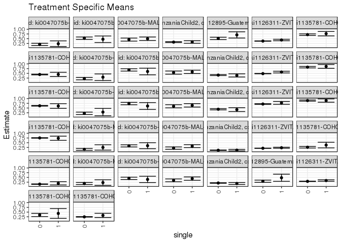

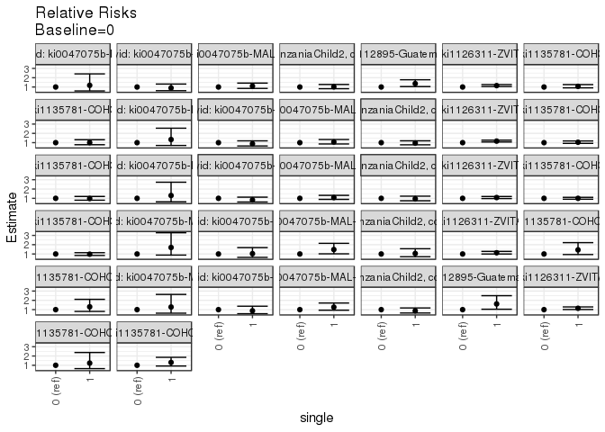

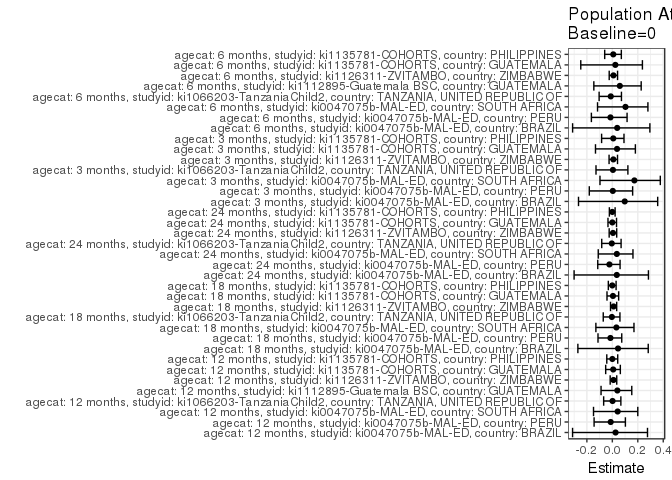

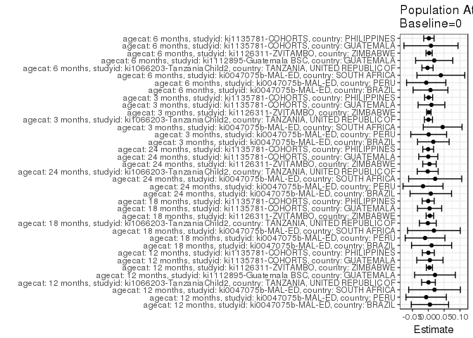

## Results Table

### Parameter: TSM

| agecat | studyid | country | intervention_level | baseline_level | estimate | ci_lower | ci_upper |
| --- | --- | --- | --- | --- | --- | --- | --- |
| 3 months | ki0047075b-MAL-ED | BRAZIL | 0 | NA | 0.1472081 | 0.0976247 | 0.1967915 |
| 3 months | ki0047075b-MAL-ED | BRAZIL | 1 | NA | 0.2500000 | 0.1082473 | 0.3917527 |
| 3 months | ki0047075b-MAL-ED | PERU | 0 | NA | 0.3320896 | 0.2756108 | 0.3885683 |
| 3 months | ki0047075b-MAL-ED | PERU | 1 | NA | 0.3428571 | 0.1853434 | 0.5003709 |
| 3 months | ki0047075b-MAL-ED | SOUTH AFRICA | 0 | NA | 0.2159091 | 0.1550251 | 0.2767931 |
| 3 months | ki0047075b-MAL-ED | SOUTH AFRICA | 1 | NA | 0.3188406 | 0.2409630 | 0.3967181 |
| 3 months | ki1066203-TanzaniaChild2 | TANZANIA, UNITED REPUBLIC OF | 0 | NA | 0.1019553 | 0.0891563 | 0.1147543 |
| 3 months | ki1066203-TanzaniaChild2 | TANZANIA, UNITED REPUBLIC OF | 1 | NA | 0.1071429 | 0.0666304 | 0.1476553 |
| 3 months | ki1126311-ZVITAMBO | ZIMBABWE | 0 | NA | 0.2080691 | 0.2011142 | 0.2150240 |
| 3 months | ki1126311-ZVITAMBO | ZIMBABWE | 1 | NA | 0.2347630 | 0.2068530 | 0.2626730 |
| 3 months | ki1135781-COHORTS | GUATEMALA | 0 | NA | 0.2601432 | 0.2180904 | 0.3021960 |
| 3 months | ki1135781-COHORTS | GUATEMALA | 1 | NA | 0.3750000 | 0.2248078 | 0.5251922 |
| 3 months | ki1135781-COHORTS | PHILIPPINES | 0 | NA | 0.1431486 | 0.1304890 | 0.1558082 |
| 3 months | ki1135781-COHORTS | PHILIPPINES | 1 | NA | 0.1866667 | 0.0984690 | 0.2748643 |
| 6 months | ki0047075b-MAL-ED | BRAZIL | 0 | NA | 0.1764706 | 0.1217058 | 0.2312354 |
| 6 months | ki0047075b-MAL-ED | BRAZIL | 1 | NA | 0.2258065 | 0.0782838 | 0.3733291 |
| 6 months | ki0047075b-MAL-ED | PERU | 0 | NA | 0.4497992 | 0.3878993 | 0.5116991 |
| 6 months | ki0047075b-MAL-ED | PERU | 1 | NA | 0.3939394 | 0.2269322 | 0.5609466 |
| 6 months | ki0047075b-MAL-ED | SOUTH AFRICA | 0 | NA | 0.3441558 | 0.2689817 | 0.4193300 |
| 6 months | ki0047075b-MAL-ED | SOUTH AFRICA | 1 | NA | 0.4358974 | 0.3458795 | 0.5259154 |
| 6 months | ki1066203-TanzaniaChild2 | TANZANIA, UNITED REPUBLIC OF | 0 | NA | 0.2032803 | 0.1856917 | 0.2208690 |
| 6 months | ki1066203-TanzaniaChild2 | TANZANIA, UNITED REPUBLIC OF | 1 | NA | 0.1764706 | 0.1241459 | 0.2287953 |
| 6 months | ki1112895-Guatemala BSC | GUATEMALA | 0 | NA | 0.2983193 | 0.2400834 | 0.3565553 |
| 6 months | ki1112895-Guatemala BSC | GUATEMALA | 1 | NA | 0.4814815 | 0.2926566 | 0.6703063 |
| 6 months | ki1126311-ZVITAMBO | ZIMBABWE | 0 | NA | 0.2920635 | 0.2823992 | 0.3017278 |
| 6 months | ki1126311-ZVITAMBO | ZIMBABWE | 1 | NA | 0.3339286 | 0.2948656 | 0.3729915 |
| 6 months | ki1135781-COHORTS | GUATEMALA | 0 | NA | 0.3471074 | 0.2619696 | 0.4322453 |
| 6 months | ki1135781-COHORTS | GUATEMALA | 1 | NA | 0.4285714 | 0.1683811 | 0.6887618 |
| 6 months | ki1135781-COHORTS | PHILIPPINES | 0 | NA | 0.2475028 | 0.2312306 | 0.2637750 |
| 6 months | ki1135781-COHORTS | PHILIPPINES | 1 | NA | 0.3235294 | 0.2123170 | 0.4347418 |
| 12 months | ki0047075b-MAL-ED | BRAZIL | 0 | NA | 0.1977401 | 0.1389211 | 0.2565592 |
| 12 months | ki0047075b-MAL-ED | BRAZIL | 1 | NA | 0.2333333 | 0.0816176 | 0.3850491 |
| 12 months | ki0047075b-MAL-ED | PERU | 0 | NA | 0.5252101 | 0.4616503 | 0.5887699 |
| 12 months | ki0047075b-MAL-ED | PERU | 1 | NA | 0.4687500 | 0.2955296 | 0.6419704 |
| 12 months | ki0047075b-MAL-ED | SOUTH AFRICA | 0 | NA | 0.4513889 | 0.3699532 | 0.5328245 |
| 12 months | ki0047075b-MAL-ED | SOUTH AFRICA | 1 | NA | 0.4956522 | 0.4040949 | 0.5872094 |
| 12 months | ki1066203-TanzaniaChild2 | TANZANIA, UNITED REPUBLIC OF | 0 | NA | 0.3179800 | 0.2964731 | 0.3394870 |
| 12 months | ki1066203-TanzaniaChild2 | TANZANIA, UNITED REPUBLIC OF | 1 | NA | 0.3240223 | 0.2554443 | 0.3926004 |
| 12 months | ki1112895-Guatemala BSC | GUATEMALA | 0 | NA | 0.5127119 | 0.4488209 | 0.5766028 |
| 12 months | ki1112895-Guatemala BSC | GUATEMALA | 1 | NA | 0.7000000 | 0.5357085 | 0.8642915 |
| 12 months | ki1126311-ZVITAMBO | ZIMBABWE | 0 | NA | 0.3735294 | 0.3638117 | 0.3832471 |
| 12 months | ki1126311-ZVITAMBO | ZIMBABWE | 1 | NA | 0.4297125 | 0.3909315 | 0.4684934 |
| 12 months | ki1135781-COHORTS | GUATEMALA | 0 | NA | 0.7145969 | 0.6732420 | 0.7559519 |
| 12 months | ki1135781-COHORTS | GUATEMALA | 1 | NA | 0.7647059 | 0.6481748 | 0.8812370 |
| 12 months | ki1135781-COHORTS | PHILIPPINES | 0 | NA | 0.4395935 | 0.4207176 | 0.4584695 |
| 12 months | ki1135781-COHORTS | PHILIPPINES | 1 | NA | 0.4444444 | 0.3296466 | 0.5592423 |
| 18 months | ki0047075b-MAL-ED | BRAZIL | 0 | NA | 0.2215569 | 0.1584076 | 0.2847061 |
| 18 months | ki0047075b-MAL-ED | BRAZIL | 1 | NA | 0.2962963 | 0.1236145 | 0.4689780 |
| 18 months | ki0047075b-MAL-ED | PERU | 0 | NA | 0.6822430 | 0.6197329 | 0.7447531 |
| 18 months | ki0047075b-MAL-ED | PERU | 1 | NA | 0.6000000 | 0.4243352 | 0.7756648 |
| 18 months | ki0047075b-MAL-ED | SOUTH AFRICA | 0 | NA | 0.5395683 | 0.4565438 | 0.6225929 |
| 18 months | ki0047075b-MAL-ED | SOUTH AFRICA | 1 | NA | 0.5789474 | 0.4881353 | 0.6697594 |
| 18 months | ki1066203-TanzaniaChild2 | TANZANIA, UNITED REPUBLIC OF | 0 | NA | 0.4071537 | 0.3805801 | 0.4337274 |
| 18 months | ki1066203-TanzaniaChild2 | TANZANIA, UNITED REPUBLIC OF | 1 | NA | 0.3909774 | 0.3080182 | 0.4739367 |
| 18 months | ki1126311-ZVITAMBO | ZIMBABWE | 0 | NA | 0.4862601 | 0.4743841 | 0.4981361 |
| 18 months | ki1126311-ZVITAMBO | ZIMBABWE | 1 | NA | 0.5679287 | 0.5221062 | 0.6137513 |
| 18 months | ki1135781-COHORTS | GUATEMALA | 0 | NA | 0.8280423 | 0.7899574 | 0.8661273 |
| 18 months | ki1135781-COHORTS | GUATEMALA | 1 | NA | 0.8666667 | 0.7672289 | 0.9661044 |
| 18 months | ki1135781-COHORTS | PHILIPPINES | 0 | NA | 0.6195353 | 0.6006471 | 0.6384234 |
| 18 months | ki1135781-COHORTS | PHILIPPINES | 1 | NA | 0.6065574 | 0.4839424 | 0.7291723 |
| 24 months | ki0047075b-MAL-ED | BRAZIL | 0 | NA | 0.2193548 | 0.1540237 | 0.2846859 |
| 24 months | ki0047075b-MAL-ED | BRAZIL | 1 | NA | 0.2857143 | 0.0919482 | 0.4794803 |
| 24 months | ki0047075b-MAL-ED | PERU | 0 | NA | 0.7368421 | 0.6740847 | 0.7995995 |
| 24 months | ki0047075b-MAL-ED | PERU | 1 | NA | 0.6071429 | 0.4258293 | 0.7884564 |
| 24 months | ki0047075b-MAL-ED | SOUTH AFRICA | 0 | NA | 0.5939850 | 0.5103515 | 0.6776185 |
| 24 months | ki0047075b-MAL-ED | SOUTH AFRICA | 1 | NA | 0.6422018 | 0.5520263 | 0.7323774 |
| 24 months | ki1066203-TanzaniaChild2 | TANZANIA, UNITED REPUBLIC OF | 0 | NA | 0.4361335 | 0.4031450 | 0.4691220 |
| 24 months | ki1066203-TanzaniaChild2 | TANZANIA, UNITED REPUBLIC OF | 1 | NA | 0.4157303 | 0.3132850 | 0.5181757 |
| 24 months | ki1126311-ZVITAMBO | ZIMBABWE | 0 | NA | 0.7125783 | 0.6914115 | 0.7337450 |
| 24 months | ki1126311-ZVITAMBO | ZIMBABWE | 1 | NA | 0.7711864 | 0.6953735 | 0.8469994 |
| 24 months | ki1135781-COHORTS | GUATEMALA | 0 | NA | 0.8964646 | 0.8664246 | 0.9265047 |
| 24 months | ki1135781-COHORTS | GUATEMALA | 1 | NA | 0.8958333 | 0.8093176 | 0.9823491 |
| 24 months | ki1135781-COHORTS | PHILIPPINES | 0 | NA | 0.7534413 | 0.7364405 | 0.7704421 |
| 24 months | ki1135781-COHORTS | PHILIPPINES | 1 | NA | 0.7377049 | 0.6272957 | 0.8481142 |

### Parameter: E(Y)

| agecat | studyid | country | intervention_level | baseline_level | estimate | ci_lower | ci_upper |
| --- | --- | --- | --- | --- | --- | --- | --- |
| 3 months | ki0047075b-MAL-ED | BRAZIL | NA | NA | 0.1630901 | 0.1583094 | 0.1678708 |
| 3 months | ki0047075b-MAL-ED | PERU | NA | NA | 0.3333333 | 0.3329452 | 0.3337215 |
| 3 months | ki0047075b-MAL-ED | SOUTH AFRICA | NA | NA | 0.2611465 | 0.2554868 | 0.2668062 |
| 3 months | ki1066203-TanzaniaChild2 | TANZANIA, UNITED REPUBLIC OF | NA | NA | 0.1024452 | 0.1023841 | 0.1025063 |
| 3 months | ki1126311-ZVITAMBO | ZIMBABWE | NA | NA | 0.2097617 | 0.2096538 | 0.2098695 |
| 3 months | ki1135781-COHORTS | GUATEMALA | NA | NA | 0.2701525 | 0.2671856 | 0.2731194 |
| 3 months | ki1135781-COHORTS | PHILIPPINES | NA | NA | 0.1442308 | 0.1439889 | 0.1444727 |
| 6 months | ki0047075b-MAL-ED | BRAZIL | NA | NA | 0.1834862 | 0.1811937 | 0.1857788 |
| 6 months | ki0047075b-MAL-ED | PERU | NA | NA | 0.4432624 | 0.4411630 | 0.4453618 |
| 6 months | ki0047075b-MAL-ED | SOUTH AFRICA | NA | NA | 0.3837638 | 0.3783436 | 0.3891841 |
| 6 months | ki1066203-TanzaniaChild2 | TANZANIA, UNITED REPUBLIC OF | NA | NA | 0.2008123 | 0.2004895 | 0.2011351 |
| 6 months | ki1112895-Guatemala BSC | GUATEMALA | NA | NA | 0.3169811 | 0.3102976 | 0.3236647 |
| 6 months | ki1126311-ZVITAMBO | ZIMBABWE | NA | NA | 0.2946498 | 0.2944423 | 0.2948572 |
| 6 months | ki1135781-COHORTS | GUATEMALA | NA | NA | 0.3555556 | 0.3513504 | 0.3597607 |
| 6 months | ki1135781-COHORTS | PHILIPPINES | NA | NA | 0.2493685 | 0.2489304 | 0.2498065 |
| 12 months | ki0047075b-MAL-ED | BRAZIL | NA | NA | 0.2028986 | 0.2011875 | 0.2046096 |
| 12 months | ki0047075b-MAL-ED | PERU | NA | NA | 0.5185185 | 0.5163377 | 0.5206993 |
| 12 months | ki0047075b-MAL-ED | SOUTH AFRICA | NA | NA | 0.4710425 | 0.4683589 | 0.4737260 |
| 12 months | ki1066203-TanzaniaChild2 | TANZANIA, UNITED REPUBLIC OF | NA | NA | 0.3185260 | 0.3184497 | 0.3186023 |
| 12 months | ki1112895-Guatemala BSC | GUATEMALA | NA | NA | 0.5338346 | 0.5267016 | 0.5409676 |
| 12 months | ki1126311-ZVITAMBO | ZIMBABWE | NA | NA | 0.3769959 | 0.3767328 | 0.3772589 |
| 12 months | ki1135781-COHORTS | GUATEMALA | NA | NA | 0.7196078 | 0.7183019 | 0.7209138 |
| 12 months | ki1135781-COHORTS | PHILIPPINES | NA | NA | 0.4397215 | 0.4396923 | 0.4397507 |
| 18 months | ki0047075b-MAL-ED | BRAZIL | NA | NA | 0.2319588 | 0.2283091 | 0.2356085 |
| 18 months | ki0047075b-MAL-ED | PERU | NA | NA | 0.6721311 | 0.6687355 | 0.6755268 |
| 18 months | ki0047075b-MAL-ED | SOUTH AFRICA | NA | NA | 0.5573123 | 0.5548932 | 0.5597313 |
| 18 months | ki1066203-TanzaniaChild2 | TANZANIA, UNITED REPUBLIC OF | NA | NA | 0.4056669 | 0.4054260 | 0.4059078 |
| 18 months | ki1126311-ZVITAMBO | ZIMBABWE | NA | NA | 0.4913151 | 0.4908622 | 0.4917680 |
| 18 months | ki1135781-COHORTS | GUATEMALA | NA | NA | 0.8321513 | 0.8310151 | 0.8332875 |
| 18 months | ki1135781-COHORTS | PHILIPPINES | NA | NA | 0.6192308 | 0.6191552 | 0.6193063 |
| 24 months | ki0047075b-MAL-ED | BRAZIL | NA | NA | 0.2272727 | 0.2240856 | 0.2304598 |
| 24 months | ki0047075b-MAL-ED | PERU | NA | NA | 0.7201835 | 0.7144098 | 0.7259572 |
| 24 months | ki0047075b-MAL-ED | SOUTH AFRICA | NA | NA | 0.6157025 | 0.6126737 | 0.6187312 |
| 24 months | ki1066203-TanzaniaChild2 | TANZANIA, UNITED REPUBLIC OF | NA | NA | 0.4342380 | 0.4338627 | 0.4346133 |
| 24 months | ki1126311-ZVITAMBO | ZIMBABWE | NA | NA | 0.7162667 | 0.7156223 | 0.7169111 |
| 24 months | ki1135781-COHORTS | GUATEMALA | NA | NA | 0.8963964 | 0.8963781 | 0.8964147 |
| 24 months | ki1135781-COHORTS | PHILIPPINES | NA | NA | 0.7530620 | 0.7529680 | 0.7531561 |

### Parameter: RR

| agecat | studyid | country | intervention_level | baseline_level | estimate | ci_lower | ci_upper |
| --- | --- | --- | --- | --- | --- | --- | --- |
| 3 months | ki0047075b-MAL-ED | BRAZIL | 0 | 0 | 1.0000000 | 1.0000000 | 1.000000 |
| 3 months | ki0047075b-MAL-ED | BRAZIL | 1 | 0 | 1.6982759 | 0.8781869 | 3.284199 |
| 3 months | ki0047075b-MAL-ED | PERU | 0 | 0 | 1.0000000 | 1.0000000 | 1.000000 |
| 3 months | ki0047075b-MAL-ED | PERU | 1 | 0 | 1.0324238 | 0.6325634 | 1.685046 |
| 3 months | ki0047075b-MAL-ED | SOUTH AFRICA | 0 | 0 | 1.0000000 | 1.0000000 | 1.000000 |
| 3 months | ki0047075b-MAL-ED | SOUTH AFRICA | 1 | 0 | 1.4767353 | 1.0169108 | 2.144482 |
| 3 months | ki1066203-TanzaniaChild2 | TANZANIA, UNITED REPUBLIC OF | 0 | 0 | 1.0000000 | 1.0000000 | 1.000000 |
| 3 months | ki1066203-TanzaniaChild2 | TANZANIA, UNITED REPUBLIC OF | 1 | 0 | 1.0508806 | 0.7055470 | 1.565240 |
| 3 months | ki1126311-ZVITAMBO | ZIMBABWE | 0 | 0 | 1.0000000 | 1.0000000 | 1.000000 |
| 3 months | ki1126311-ZVITAMBO | ZIMBABWE | 1 | 0 | 1.1282935 | 0.9972147 | 1.276602 |
| 3 months | ki1135781-COHORTS | GUATEMALA | 0 | 0 | 1.0000000 | 1.0000000 | 1.000000 |
| 3 months | ki1135781-COHORTS | GUATEMALA | 1 | 0 | 1.4415138 | 0.9359333 | 2.220203 |
| 3 months | ki1135781-COHORTS | PHILIPPINES | 0 | 0 | 1.0000000 | 1.0000000 | 1.000000 |
| 3 months | ki1135781-COHORTS | PHILIPPINES | 1 | 0 | 1.3040063 | 0.8063387 | 2.108832 |
| 6 months | ki0047075b-MAL-ED | BRAZIL | 0 | 0 | 1.0000000 | 1.0000000 | 1.000000 |
| 6 months | ki0047075b-MAL-ED | BRAZIL | 1 | 0 | 1.2795699 | 0.6207971 | 2.637414 |
| 6 months | ki0047075b-MAL-ED | PERU | 0 | 0 | 1.0000000 | 1.0000000 | 1.000000 |
| 6 months | ki0047075b-MAL-ED | PERU | 1 | 0 | 0.8758117 | 0.5608385 | 1.367677 |
| 6 months | ki0047075b-MAL-ED | SOUTH AFRICA | 0 | 0 | 1.0000000 | 1.0000000 | 1.000000 |
| 6 months | ki0047075b-MAL-ED | SOUTH AFRICA | 1 | 0 | 1.2665699 | 0.9377374 | 1.710713 |
| 6 months | ki1066203-TanzaniaChild2 | TANZANIA, UNITED REPUBLIC OF | 0 | 0 | 1.0000000 | 1.0000000 | 1.000000 |
| 6 months | ki1066203-TanzaniaChild2 | TANZANIA, UNITED REPUBLIC OF | 1 | 0 | 0.8681145 | 0.6374338 | 1.182276 |
| 6 months | ki1112895-Guatemala BSC | GUATEMALA | 0 | 0 | 1.0000000 | 1.0000000 | 1.000000 |
| 6 months | ki1112895-Guatemala BSC | GUATEMALA | 1 | 0 | 1.6139802 | 1.0414655 | 2.501218 |
| 6 months | ki1126311-ZVITAMBO | ZIMBABWE | 0 | 0 | 1.0000000 | 1.0000000 | 1.000000 |
| 6 months | ki1126311-ZVITAMBO | ZIMBABWE | 1 | 0 | 1.1433424 | 1.0124630 | 1.291140 |
| 6 months | ki1135781-COHORTS | GUATEMALA | 0 | 0 | 1.0000000 | 1.0000000 | 1.000000 |
| 6 months | ki1135781-COHORTS | GUATEMALA | 1 | 0 | 1.2346939 | 0.6414891 | 2.376453 |
| 6 months | ki1135781-COHORTS | PHILIPPINES | 0 | 0 | 1.0000000 | 1.0000000 | 1.000000 |
| 6 months | ki1135781-COHORTS | PHILIPPINES | 1 | 0 | 1.3071749 | 0.9211705 | 1.854929 |
| 12 months | ki0047075b-MAL-ED | BRAZIL | 0 | 0 | 1.0000000 | 1.0000000 | 1.000000 |
| 12 months | ki0047075b-MAL-ED | BRAZIL | 1 | 0 | 1.1800000 | 0.5772351 | 2.412189 |
| 12 months | ki0047075b-MAL-ED | PERU | 0 | 0 | 1.0000000 | 1.0000000 | 1.000000 |
| 12 months | ki0047075b-MAL-ED | PERU | 1 | 0 | 0.8925000 | 0.6049698 | 1.316688 |
| 12 months | ki0047075b-MAL-ED | SOUTH AFRICA | 0 | 0 | 1.0000000 | 1.0000000 | 1.000000 |
| 12 months | ki0047075b-MAL-ED | SOUTH AFRICA | 1 | 0 | 1.0980602 | 0.8481819 | 1.421554 |
| 12 months | ki1066203-TanzaniaChild2 | TANZANIA, UNITED REPUBLIC OF | 0 | 0 | 1.0000000 | 1.0000000 | 1.000000 |
| 12 months | ki1066203-TanzaniaChild2 | TANZANIA, UNITED REPUBLIC OF | 1 | 0 | 1.0190022 | 0.8159790 | 1.272539 |
| 12 months | ki1112895-Guatemala BSC | GUATEMALA | 0 | 0 | 1.0000000 | 1.0000000 | 1.000000 |
| 12 months | ki1112895-Guatemala BSC | GUATEMALA | 1 | 0 | 1.3652893 | 1.0466912 | 1.780864 |
| 12 months | ki1126311-ZVITAMBO | ZIMBABWE | 0 | 0 | 1.0000000 | 1.0000000 | 1.000000 |
| 12 months | ki1126311-ZVITAMBO | ZIMBABWE | 1 | 0 | 1.1504113 | 1.0472797 | 1.263699 |
| 12 months | ki1135781-COHORTS | GUATEMALA | 0 | 0 | 1.0000000 | 1.0000000 | 1.000000 |
| 12 months | ki1135781-COHORTS | GUATEMALA | 1 | 0 | 1.0701220 | 0.9091609 | 1.259580 |
| 12 months | ki1135781-COHORTS | PHILIPPINES | 0 | 0 | 1.0000000 | 1.0000000 | 1.000000 |
| 12 months | ki1135781-COHORTS | PHILIPPINES | 1 | 0 | 1.0110350 | 0.7781270 | 1.313657 |
| 18 months | ki0047075b-MAL-ED | BRAZIL | 0 | 0 | 1.0000000 | 1.0000000 | 1.000000 |
| 18 months | ki0047075b-MAL-ED | BRAZIL | 1 | 0 | 1.3373373 | 0.6990140 | 2.558563 |
| 18 months | ki0047075b-MAL-ED | PERU | 0 | 0 | 1.0000000 | 1.0000000 | 1.000000 |
| 18 months | ki0047075b-MAL-ED | PERU | 1 | 0 | 0.8794521 | 0.6471138 | 1.195208 |
| 18 months | ki0047075b-MAL-ED | SOUTH AFRICA | 0 | 0 | 1.0000000 | 1.0000000 | 1.000000 |
| 18 months | ki0047075b-MAL-ED | SOUTH AFRICA | 1 | 0 | 1.0729825 | 0.8613220 | 1.336656 |
| 18 months | ki1066203-TanzaniaChild2 | TANZANIA, UNITED REPUBLIC OF | 0 | 0 | 1.0000000 | 1.0000000 | 1.000000 |
| 18 months | ki1066203-TanzaniaChild2 | TANZANIA, UNITED REPUBLIC OF | 1 | 0 | 0.9602698 | 0.7690985 | 1.198960 |
| 18 months | ki1126311-ZVITAMBO | ZIMBABWE | 0 | 0 | 1.0000000 | 1.0000000 | 1.000000 |
| 18 months | ki1126311-ZVITAMBO | ZIMBABWE | 1 | 0 | 1.1679526 | 1.0735309 | 1.270679 |
| 18 months | ki1135781-COHORTS | GUATEMALA | 0 | 0 | 1.0000000 | 1.0000000 | 1.000000 |
| 18 months | ki1135781-COHORTS | GUATEMALA | 1 | 0 | 1.0466454 | 0.9249449 | 1.184359 |
| 18 months | ki1135781-COHORTS | PHILIPPINES | 0 | 0 | 1.0000000 | 1.0000000 | 1.000000 |
| 18 months | ki1135781-COHORTS | PHILIPPINES | 1 | 0 | 0.9790522 | 0.7980330 | 1.201132 |
| 24 months | ki0047075b-MAL-ED | BRAZIL | 0 | 0 | 1.0000000 | 1.0000000 | 1.000000 |
| 24 months | ki0047075b-MAL-ED | BRAZIL | 1 | 0 | 1.3025210 | 0.6210170 | 2.731908 |
| 24 months | ki0047075b-MAL-ED | PERU | 0 | 0 | 1.0000000 | 1.0000000 | 1.000000 |
| 24 months | ki0047075b-MAL-ED | PERU | 1 | 0 | 0.8239796 | 0.6040178 | 1.124044 |
| 24 months | ki0047075b-MAL-ED | SOUTH AFRICA | 0 | 0 | 1.0000000 | 1.0000000 | 1.000000 |
| 24 months | ki0047075b-MAL-ED | SOUTH AFRICA | 1 | 0 | 1.0811752 | 0.8862095 | 1.319033 |
| 24 months | ki1066203-TanzaniaChild2 | TANZANIA, UNITED REPUBLIC OF | 0 | 0 | 1.0000000 | 1.0000000 | 1.000000 |
| 24 months | ki1066203-TanzaniaChild2 | TANZANIA, UNITED REPUBLIC OF | 1 | 0 | 0.9532181 | 0.7366212 | 1.233503 |
| 24 months | ki1126311-ZVITAMBO | ZIMBABWE | 0 | 0 | 1.0000000 | 1.0000000 | 1.000000 |
| 24 months | ki1126311-ZVITAMBO | ZIMBABWE | 1 | 0 | 1.0822481 | 0.9766214 | 1.199299 |
| 24 months | ki1135781-COHORTS | GUATEMALA | 0 | 0 | 1.0000000 | 1.0000000 | 1.000000 |
| 24 months | ki1135781-COHORTS | GUATEMALA | 1 | 0 | 0.9992958 | 0.9021915 | 1.106852 |
| 24 months | ki1135781-COHORTS | PHILIPPINES | 0 | 0 | 1.0000000 | 1.0000000 | 1.000000 |
| 24 months | ki1135781-COHORTS | PHILIPPINES | 1 | 0 | 0.9791140 | 0.8415882 | 1.139113 |

### Parameter: PAR

| agecat | studyid | country | intervention_level | baseline_level | estimate | ci_lower | ci_upper |
| --- | --- | --- | --- | --- | --- | --- | --- |
| 3 months | ki0047075b-MAL-ED | BRAZIL | 0 | NA | 0.0158820 | -0.0339313 | 0.0656954 |
| 3 months | ki0047075b-MAL-ED | PERU | 0 | NA | 0.0012438 | -0.0552363 | 0.0577239 |
| 3 months | ki0047075b-MAL-ED | SOUTH AFRICA | 0 | NA | 0.0452374 | -0.0159091 | 0.1063839 |
| 3 months | ki1066203-TanzaniaChild2 | TANZANIA, UNITED REPUBLIC OF | 0 | NA | 0.0004899 | -0.0123093 | 0.0132890 |
| 3 months | ki1126311-ZVITAMBO | ZIMBABWE | 0 | NA | 0.0016926 | -0.0052631 | 0.0086483 |
| 3 months | ki1135781-COHORTS | GUATEMALA | 0 | NA | 0.0100093 | -0.0321480 | 0.0521666 |
| 3 months | ki1135781-COHORTS | PHILIPPINES | 0 | NA | 0.0010822 | -0.0115797 | 0.0137441 |
| 6 months | ki0047075b-MAL-ED | BRAZIL | 0 | NA | 0.0070157 | -0.0477971 | 0.0618284 |
| 6 months | ki0047075b-MAL-ED | PERU | 0 | NA | -0.0065368 | -0.0684723 | 0.0553987 |
| 6 months | ki0047075b-MAL-ED | SOUTH AFRICA | 0 | NA | 0.0396080 | -0.0357613 | 0.1149773 |
| 6 months | ki1066203-TanzaniaChild2 | TANZANIA, UNITED REPUBLIC OF | 0 | NA | -0.0024680 | -0.0200597 | 0.0151236 |
| 6 months | ki1112895-Guatemala BSC | GUATEMALA | 0 | NA | 0.0186618 | -0.0399564 | 0.0772800 |
| 6 months | ki1126311-ZVITAMBO | ZIMBABWE | 0 | NA | 0.0025863 | -0.0070803 | 0.0122528 |
| 6 months | ki1135781-COHORTS | GUATEMALA | 0 | NA | 0.0084481 | -0.0767935 | 0.0936898 |
| 6 months | ki1135781-COHORTS | PHILIPPINES | 0 | NA | 0.0018657 | -0.0144124 | 0.0181438 |
| 12 months | ki0047075b-MAL-ED | BRAZIL | 0 | NA | 0.0051584 | -0.0536855 | 0.0640024 |
| 12 months | ki0047075b-MAL-ED | PERU | 0 | NA | -0.0066916 | -0.0702888 | 0.0569057 |
| 12 months | ki0047075b-MAL-ED | SOUTH AFRICA | 0 | NA | 0.0196536 | -0.0618263 | 0.1011334 |
| 12 months | ki1066203-TanzaniaChild2 | TANZANIA, UNITED REPUBLIC OF | 0 | NA | 0.0005460 | -0.0209611 | 0.0220531 |
| 12 months | ki1112895-Guatemala BSC | GUATEMALA | 0 | NA | 0.0211227 | -0.0431652 | 0.0854106 |
| 12 months | ki1126311-ZVITAMBO | ZIMBABWE | 0 | NA | 0.0034664 | -0.0062548 | 0.0131877 |
| 12 months | ki1135781-COHORTS | GUATEMALA | 0 | NA | 0.0050109 | -0.0363647 | 0.0463865 |
| 12 months | ki1135781-COHORTS | PHILIPPINES | 0 | NA | 0.0001280 | -0.0187480 | 0.0190040 |
| 18 months | ki0047075b-MAL-ED | BRAZIL | 0 | NA | 0.0104019 | -0.0528527 | 0.0736565 |
| 18 months | ki0047075b-MAL-ED | PERU | 0 | NA | -0.0101118 | -0.0727141 | 0.0524904 |
| 18 months | ki0047075b-MAL-ED | SOUTH AFRICA | 0 | NA | 0.0177439 | -0.0653159 | 0.1008037 |
| 18 months | ki1066203-TanzaniaChild2 | TANZANIA, UNITED REPUBLIC OF | 0 | NA | -0.0014868 | -0.0280615 | 0.0250879 |
| 18 months | ki1126311-ZVITAMBO | ZIMBABWE | 0 | NA | 0.0050550 | -0.0068296 | 0.0169397 |
| 18 months | ki1135781-COHORTS | GUATEMALA | 0 | NA | 0.0041090 | -0.0339929 | 0.0422109 |
| 18 months | ki1135781-COHORTS | PHILIPPINES | 0 | NA | -0.0003045 | -0.0191928 | 0.0185839 |
| 24 months | ki0047075b-MAL-ED | BRAZIL | 0 | NA | 0.0079179 | -0.0574909 | 0.0733267 |
| 24 months | ki0047075b-MAL-ED | PERU | 0 | NA | -0.0166586 | -0.0796811 | 0.0463638 |
| 24 months | ki0047075b-MAL-ED | SOUTH AFRICA | 0 | NA | 0.0217175 | -0.0619708 | 0.1054058 |
| 24 months | ki1066203-TanzaniaChild2 | TANZANIA, UNITED REPUBLIC OF | 0 | NA | -0.0018955 | -0.0348861 | 0.0310952 |
| 24 months | ki1126311-ZVITAMBO | ZIMBABWE | 0 | NA | 0.0036884 | -0.0174881 | 0.0248650 |
| 24 months | ki1135781-COHORTS | GUATEMALA | 0 | NA | -0.0000683 | -0.0301083 | 0.0299718 |
| 24 months | ki1135781-COHORTS | PHILIPPINES | 0 | NA | -0.0003793 | -0.0173804 | 0.0166218 |

### Parameter: PAF

| agecat | studyid | country | intervention_level | baseline_level | estimate | ci_lower | ci_upper |
| --- | --- | --- | --- | --- | --- | --- | --- |
| 3 months | ki0047075b-MAL-ED | BRAZIL | 0 | NA | 0.0973818 | -0.2657220 | 0.3563202 |
| 3 months | ki0047075b-MAL-ED | PERU | 0 | NA | 0.0037313 | -0.1809705 | 0.1595461 |
| 3 months | ki0047075b-MAL-ED | SOUTH AFRICA | 0 | NA | 0.1732262 | -0.0970190 | 0.3768978 |
| 3 months | ki1066203-TanzaniaChild2 | TANZANIA, UNITED REPUBLIC OF | 0 | NA | 0.0047819 | -0.1283355 | 0.1221946 |
| 3 months | ki1126311-ZVITAMBO | ZIMBABWE | 0 | NA | 0.0080692 | -0.0256514 | 0.0406812 |
| 3 months | ki1135781-COHORTS | GUATEMALA | 0 | NA | 0.0370506 | -0.1323223 | 0.1810887 |
| 3 months | ki1135781-COHORTS | PHILIPPINES | 0 | NA | 0.0075031 | -0.0842853 | 0.0915213 |
| 6 months | ki0047075b-MAL-ED | BRAZIL | 0 | NA | 0.0382353 | -0.3120618 | 0.2950093 |
| 6 months | ki0047075b-MAL-ED | PERU | 0 | NA | -0.0147470 | -0.1645532 | 0.1157884 |
| 6 months | ki0047075b-MAL-ED | SOUTH AFRICA | 0 | NA | 0.1032093 | -0.1162266 | 0.2795069 |
| 6 months | ki1066203-TanzaniaChild2 | TANZANIA, UNITED REPUBLIC OF | 0 | NA | -0.0122903 | -0.1037952 | 0.0716288 |
| 6 months | ki1112895-Guatemala BSC | GUATEMALA | 0 | NA | 0.0588735 | -0.1453051 | 0.2266523 |
| 6 months | ki1126311-ZVITAMBO | ZIMBABWE | 0 | NA | 0.0087774 | -0.0245783 | 0.0410472 |
| 6 months | ki1135781-COHORTS | GUATEMALA | 0 | NA | 0.0237603 | -0.2479671 | 0.2363229 |
| 6 months | ki1135781-COHORTS | PHILIPPINES | 0 | NA | 0.0074816 | -0.0599897 | 0.0706582 |
| 12 months | ki0047075b-MAL-ED | BRAZIL | 0 | NA | 0.0254237 | -0.3123551 | 0.2762638 |
| 12 months | ki0047075b-MAL-ED | PERU | 0 | NA | -0.0129052 | -0.1432940 | 0.1026132 |
| 12 months | ki0047075b-MAL-ED | SOUTH AFRICA | 0 | NA | 0.0417236 | -0.1478403 | 0.1999814 |
| 12 months | ki1066203-TanzaniaChild2 | TANZANIA, UNITED REPUBLIC OF | 0 | NA | 0.0017141 | -0.0681424 | 0.0670019 |
| 12 months | ki1112895-Guatemala BSC | GUATEMALA | 0 | NA | 0.0395679 | -0.0886693 | 0.1526997 |
| 12 months | ki1126311-ZVITAMBO | ZIMBABWE | 0 | NA | 0.0091949 | -0.0169295 | 0.0346482 |
| 12 months | ki1135781-COHORTS | GUATEMALA | 0 | NA | 0.0069634 | -0.0522308 | 0.0628275 |
| 12 months | ki1135781-COHORTS | PHILIPPINES | 0 | NA | 0.0002911 | -0.0435711 | 0.0423096 |
| 18 months | ki0047075b-MAL-ED | BRAZIL | 0 | NA | 0.0448436 | -0.2707137 | 0.2820384 |
| 18 months | ki0047075b-MAL-ED | PERU | 0 | NA | -0.0150444 | -0.1125959 | 0.0739538 |
| 18 months | ki0047075b-MAL-ED | SOUTH AFRICA | 0 | NA | 0.0318384 | -0.1292765 | 0.1699668 |
| 18 months | ki1066203-TanzaniaChild2 | TANZANIA, UNITED REPUBLIC OF | 0 | NA | -0.0036652 | -0.0713590 | 0.0597515 |
| 18 months | ki1126311-ZVITAMBO | ZIMBABWE | 0 | NA | 0.0102888 | -0.0141983 | 0.0341846 |
| 18 months | ki1135781-COHORTS | GUATEMALA | 0 | NA | 0.0049378 | -0.0419190 | 0.0496873 |
| 18 months | ki1135781-COHORTS | PHILIPPINES | 0 | NA | -0.0004917 | -0.0314644 | 0.0295509 |
| 24 months | ki0047075b-MAL-ED | BRAZIL | 0 | NA | 0.0348387 | -0.3004403 | 0.2836762 |
| 24 months | ki0047075b-MAL-ED | PERU | 0 | NA | -0.0231311 | -0.1145100 | 0.0607557 |
| 24 months | ki0047075b-MAL-ED | SOUTH AFRICA | 0 | NA | 0.0352727 | -0.1106848 | 0.1620497 |
| 24 months | ki1066203-TanzaniaChild2 | TANZANIA, UNITED REPUBLIC OF | 0 | NA | -0.0043651 | -0.0832861 | 0.0688063 |
| 24 months | ki1126311-ZVITAMBO | ZIMBABWE | 0 | NA | 0.0051495 | -0.0248592 | 0.0342795 |
| 24 months | ki1135781-COHORTS | GUATEMALA | 0 | NA | -0.0000761 | -0.0341560 | 0.0328806 |
| 24 months | ki1135781-COHORTS | PHILIPPINES | 0 | NA | -0.0005036 | -0.0233362 | 0.0218195 |